# Projet

*Objectif du graphique :*  
Ici, nous allons répondre à la question suivante : **Quels sont les types de Pokémon préférés de la communauté ?**

*Présentation :*  
Pour réaliser ce graphique, nous avons combiné deux jeux de données :

- **The complete Pokemon dataset** : Statistiques complètes des Pokémons des 8 premières générations (notamment le type)
- **Sondage de popularité** : Sondage réalisé en 2019 sur un forum de la communauté Pokémon recueillant le Pokémon préféré de 52000 votants

Nous considérons ici seulement le premier type de chaque Pokémon (certains Pokémons ont un deuxième type, mais on peut considérer qu’il est moins caractérisant que le premier).  
On affiche ici, pour chacun des types, le pourcentage de vote reçu par l’ensemble des Pokémons de ce type.  
Pour mettre en perspective ces résultats, on affiche également la distribution des Pokémons par type. Les Pokémons dessinés sont les plus populaires pour chacun des types.

*Code et Visualisation*

```r
library(tidyverse)
```

[figure not shown]

```r
library(ggimage)

# Load data
popularity <- tibble(read.table("data/popularity.txt", header = TRUE, sep = ","))
pok_data <- tibble(read.csv2("data/Pokemon_data.csv", header = TRUE, sep=','))

# Join datasets by Pokemon name
merged <- popularity %>% left_join(pok_data %>% select(name, type1), by = c("Pokemon" = "name"))

# Create aggregated data by Pokemon type
type_summary <- merged %>%
  filter(!is.na(type1)) %>%
  group_by(type1) %>%
  summarise(TotalVotes = sum(Number.of.votes), Count = n()) %>%
  mutate(AvgVotes = TotalVotes / Count) %>%
  arrange(desc(AvgVotes)) %>%
  left_join(
    # Select the most popular Pokemon for each type
    merged %>%
    filter(!is.na(type1)) %>%
    group_by(type1) %>%
    slice_max(Number.of.votes, n = 1) %>%
    select(type1, Pokemon, Number.of.votes),
    by = "type1"
  ) %>%
  mutate(img_path = paste0("data/images/", tolower(Pokemon), ".png"))

# Define colors of each type for graphical purpose
type_colors <-c(
    'Normal'= '#A8A77A',
    'Fire' = '#EE8130',
    'Water' = '#6390F0',
    'Electric' = '#F7D02C',
    'Grass' = '#7AC74C',
    'Ice' = '#96D9D6',
    'Fighting' = '#C22E28',
    'Poison' = '#A33EA1',
    'Ground' = '#E2BF65',
    'Flying' = '#A98FF3',
    'Psychic' = '#F95587',
    'Bug' = '#A6B91A',
    'Rock' = '#B6A136',
    'Ghost' = '#735797',
    'Dragon' = '#6F35FC',
    'Dark' = '#705746',
    'Steel' = '#B7B7CE',
    'Fairy' = '#D685AD'
)

# Compute the average number of votes
avg_votes <- mean(type_summary$TotalVotes) / sum(type_summary$TotalVotes) * 100

# Draw graph
type_summary %>%
  ggplot(aes(x = reorder(type1, -TotalVotes),
             y = TotalVotes / sum(TotalVotes) * 100,
             fill=type1)) +
  # Colored bars
  geom_col() +
  geom_hline(yintercept = avg_votes, linetype = "dashed", color = "red", linewidth = 1, alpha=.5) +

  # Black bars
  geom_col(aes(y = Count / sum(Count) * 100, fill = "Nombre de Pokémons"), alpha = 0.3, width = 0.6) +

  # Fake invisible layer to create "Nombre de Votes" legend
  geom_col(aes(y = 0, fill = "Nombre de Votes"), show.legend = TRUE) +

  scale_fill_manual(
    name = NULL,
    values = c(type_colors, "Nombre de Pokémons" = "black", "Nombre de Votes" = "#6390F0"),
    breaks = c("Nombre de Votes", "Nombre de Pokémons")
  ) +
  guides(
    fill = guide_legend(override.aes = list(alpha = c(1, 0.3)))
  ) +

  annotate("text", x = 14, y = avg_votes + 1, label = "Popularité moyenne", color = "red", size = 4, hjust = 0) +
  labs(title = "Popularité des types de Pokemon", subtitle = "Nombre de votes par type", x = "Type", y = "%") +
  theme_minimal() +
  theme(axis.text.x = element_text(angle = 45, hjust = 1), legend.position = c(0.85, 0.85)) +

  geom_image(aes(image=img_path, y = TotalVotes / sum(TotalVotes) * 100 + 1), size=.2)
```

*Analyse :*

Tout d’abord, il est intéressant d’observer que les 3 types ayant reçu le plus grand nombre de vote sont les 3 types de base (**Eau**, **Feu** et **Plante**). Presque 40% des votes se sont tournés vers ces types, notamment grâce aux Pokémons **starters** (Pokémons de départ) qui sont très populaires. Bien que le type **Eau** arrive en tête du trio, les Pokémons **Eau** étant assez largement les plus représentés, ils sont, en proportion, bien moins appréciés que les Pokémons **Feu**.

De même, le type **Normal** arrive en quatrième position, mais cela semble surtout s’expliquer par le nombre très important de Pokémons de ce type. Les types **Insecte** et **Roche** ont également reçu un nombre de vote très faible en comparaison de leur nombre.

A l’inverse, les types **Ténèbres**, **Spectre** et **Dragon** ont été beaucoup cités malgré le nombre de Pokémons assez modeste.

Le grand gagnant de ce sondage apparaît assez clairement : il s’agit du type **Feu**

## Répartition des types par génération

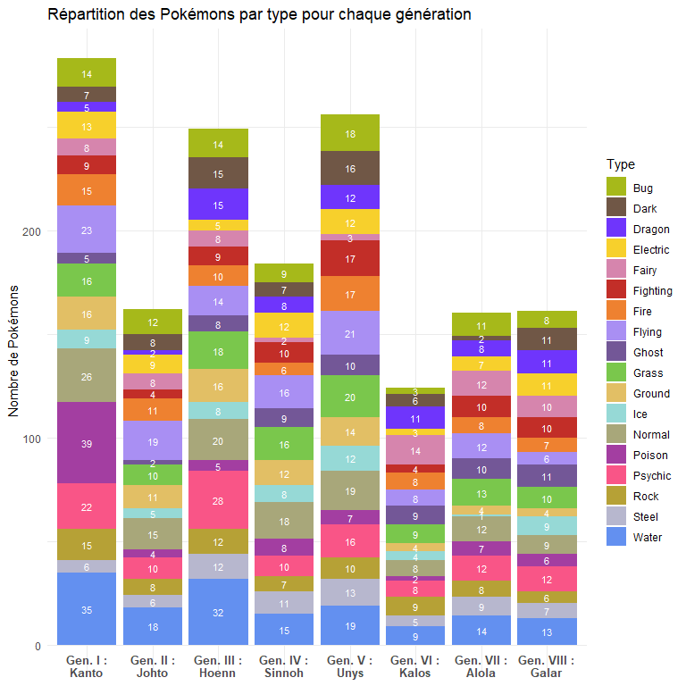

```r
library(tidyverse)

pok_data <- tibble(read.csv2("data/Pokemon_data.csv", header = TRUE, sep=','))

pok_types <- pok_data %>%
  pivot_longer(cols = c(type1, type2), names_to = "slot", values_to = "type") %>%
  filter(type != "None") %>%
  mutate(
    dummy = "types"
  )

pok_types %>%
  ggplot(aes(x = factor(generation), fill = type)) +
  geom_bar(position = "stack") +
  geom_text(stat = "count", aes(label = after_stat(count)),
            position = position_stack(vjust = 0.5), size = 3, color = "white") +

  scale_fill_manual(values = type_colors) +
  labs(
    title = "Répartition des Pokémons par type pour chaque génération",
    x = "Génération",
    y = "Nombre de Pokémons",
    fill = "Type") +
  scale_x_discrete(labels = c(
    `1` = "Gen. I :\nKanto",
    `2` = "Gen. II :\nJohto",
    `3` = "Gen. III :\nHoenn",
    `4` = "Gen. IV :\nSinnoh",
    `5` = "Gen. V :\nUnys",
    `6` = "Gen. VI :\nKalos",
    `7` = "Gen. VII :\nAlola",
    `8` = "Gen. VIII :\nGalar"
  )) +
  theme_minimal() +
  theme(
    axis.title.x = element_blank(),
    axis.text.x = element_text(size = 10, face = 'bold', margin = margin(t = -20)),
  )
```